## How Well Are You Doing Exercise?

**Constructing a Model to guide you through a Qualified Weight Lifting exercise**

*Author - Kewen Chen Sep/10/2014*

*R version 3.0.2 (2013-09-25) Platform: x86_64-pc-linux-gnu (64-bit)*

### Abstract

In this digital era, it is generally accepted that people have begun to use digital wearable devices to individually monitor self movements, especially those closely related to body health, such as heart rate, calory consumption during the physical exercises, trying to find patterns in order to improve personal health. But a phenomenon most people would be ignoring is that **How Well You Are Doing** those exercises, in general, people only care about *how much* an activity they usually do, they don’t care or totally have no sense *how well* they are doing this kind of activities, in fact, the quality of an activity or exercise is highly essential to achieve the health improvement, disqualified exercise may even harm the personal health. This report is essentially commissioned to find out a model by means of practical machine learning technique based on the experimental signal data collected from the sensors fixed on different parts of the body of 6 participants, each of the participants performed arm dumbbell lifting in 5 different behaviours, the practical model we will be exploring is to classify each of these behaviours distinctly with acceptable low error rate, the methodologies include exploratory data analysis, model feature selection, data preprocessing and practical machine learning model selection, the promissing result we acquired is a positive sign of success for this kind of experiments.

## 1 Introduction

We will be using the data provided by Groupware1, the data was collected by the experiment in which 6 participants (all males, aged between 20-28) were asked to perform one set of 10 repetitions of the Unilateral Dumbbell Biceps Curl in five different fashions (behaviours): exactly according to the specification (Class A), throwing elbows to the front (Class B), lifting the dumbbell only halfway (Class C), lowering the dumbbell only halfway (Class D) and throwing the hips to the front (Class E), only A fashion was following the standard, the others correspond to common mistakes. To measure these, on-body sensors were put on four different parts of each individual participant, through performing the aforementioned activies under instructions, signal data were caught using sliding window approach with different lengths from 0.5 second to 2.5 seconds with 0.5 second overlap, and features were calculated on the Euler angles, raw accelerometer, gyroscope and magnetometer readings. By downloading the training and testing data sets from below links, we found out that there are 160 features in each data set, start from this point we try to consturct our practical machine learning model to get the classification job done.

*Training set:* https://d396qusza40orc.cloudfront.net/predmachlearn/pml-training.csv

*Testing set:* https://d396qusza40orc.cloudfront.net/predmachlearn/pml-testing.csv

## 2 Methodology

### 2.1 Exploratory Data Analysis

Let’s download the data sets first:

```r
setwd("/home/mc/R wd")
# Download the data file and read the data into R:
if (!file.exists("./data/pml-training.csv")) {
    download.file("https://d396qusza40orc.cloudfront.net/predmachlearn/pml-training.csv",
                    destfile = "./data/pml-training.csv", quiet = T,
                    method = "curl")
}
if (!file.exists("./data/pml-testing.csv")) {
    download.file("https://d396qusza40orc.cloudfront.net/predmachlearn/pml-testing.csv",
                    destfile = "./data/pml-testing.csv", quiet = T,
                    method = "curl")
}
training <- read.csv("./data/pml-training.csv")
testing <- read.csv("./data/pml-testing.csv")
```

```r
kickoutCol <- sapply(training, function(x) {sum(is.na(x)) == 19216 || sum(x == "")})
# Separate the class (target) variable
class <- training$classe
```

Totally 100 columns don’t have much valid information, let’s plot one of them versus variable class to see if any observable correlation exists:

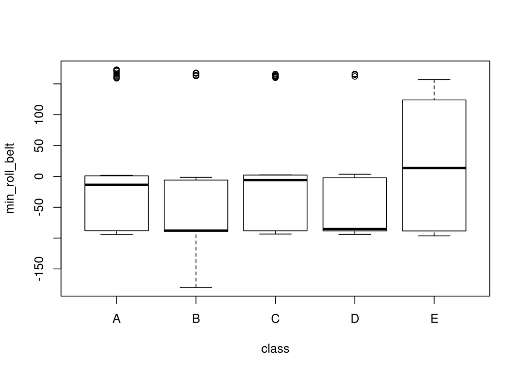

```r
oneKickout <- names(kickoutCol[kickoutCol == T])[10]  # select the 10th to be plotted.
plot(training[, oneKickout] ~ class, ylab = oneKickout)
```

Unfortunately we don’t see any correlation exists, let’s just tentatively take out all these variables from the data set to see if we can fit a reasonable model using rest of the variables.

Keep observing the data set (Figure 1.0), it is not hard to find out that variable X is just holding line sequential numbers, “user_name” for participants names, the third through seventh variables are all related to signal filtering time frames, therefore these 7 variables won’t have any effect on the class classification, plus the last variable records the classes, let’s take them out as well:

```r
kickoutCol[c(1 : 7, length(kickoutCol))] <- T   # first 7 and the last one will be kicked out.
subTrain <- training[, !kickoutCol]
```

For a central problem in machine learning is identifying a representative set of features from which to construct a classification model for a particular task. In this report, we will try correlation-based feature selection method in package “FSelector” to filter *subTrain* data set again to get the most fluential features contributed to the classification task, the principle is that any irrelevant and redundant features will be taken out, only the features which have no inter-correlations but correlations with class variable will be persisted2, besides, reduced data dimensionality will dramatically speed up the model fitting process. Let’s do this via the following code:

```r
library(FSelector)
fSel <- cfs(class ~ ., subTrain)
subTrain <- training[, fSel]
```

Have a view of *subTrain* data set via *summary(subTrain)* (Figure 2.0), each variable is numeric with no missing data, the value scale of each variable is different, thus we will consider normalizing data in the pre-processing step in constructing the model.

### 2.2 Modeling

By checking the class distribution, we acknowledged that the data were kind of symmetrically allotted between 5 classes, maybe ‘A’ class is holding more rows, but none of them is holding too few or too many, which will make it easier to fit the classification model.

```r
table(class)
```

```
## class
##    A    B    C    D    E
## 5580 3797 3422 3216 3607
```

Among all the decision tree machine learning methods, I decided to choose random forest, because it possesses substantial variance reduction ability and by inherent CV method, the testing accuracy will be much higher, no worry of overfitting on the training set. To fit this model, just one tunning parameter (mtry) which is the number of variables randomly picked as candidates at each split needs some care, different choice of this parameter may result in different accuracy rate, thus we use 10-fold CV to decide the value of this parameter during the model training. Let’s do this:

```r
library(caret)
set.seed(1002)
rfMod <- train(class ~ ., method = "rf", preProcess = c("center", "scale"),   # data normalizing
               data = subTrain, trControl = trainControl(method = "cv",number = 10))
```

Pull out the detail of this model by calling *rfMod$finalModel* (Figure 3.0), we found out that the number of trees in this random forest is 500, the tunning parameter *mtry* was chosen as 2 given the best accuracy rate which is 0.987, out-of-bag (oob) error rate is 1.04% which has the same meaning as the term out-of-sample error rate being used in other models, either the accuracy rate or oob rate is pretty promissing, almost perfect! Let’s have another view over the model plot (Figure 4.0), we see that when the model started building trees, the error rate almost dropped perpendicularly, after around 50 trees, the sliding became very slow, almost balanced, actually if you set the number of trees to grow at 100, the result is still very promissing.

## 3 Model Testing

To judge if a fitted model is right, we have to go through the testing procedure, that’s the reason why the testing data set was separated out at the beginning and never touched until the right model was found and needed the final test. Here in the *testing* data set, we got 20 lines of data without showing the corresponding classs, what we need to do is using the fitted model to predict the classs for those data lines, and submit the result to the programmed system to be graded automatically. Before predicting, the testing data set must go through the dimensional reduction as same as the training set. The code is shown as below:

```r
subTest <- testing[, fSel]
pred <- predict(rfMod, subTest)
```

## 5 Appendix

```
##        X            user_name    raw_timestamp_part_1 raw_timestamp_part_2
##  Min.   :    1   adelmo  :3892   Min.   :1.32e+09     Min.   :   294
##  1st Qu.: 4906   carlitos:3112   1st Qu.:1.32e+09     1st Qu.:252912
##  Median : 9812   charles :3536   Median :1.32e+09     Median :496380
##  Mean   : 9812   eurico  :3070   Mean   :1.32e+09     Mean   :500656
##  3rd Qu.:14717   jeremy  :3402   3rd Qu.:1.32e+09     3rd Qu.:751891
##  Max.   :19622   pedro   :2610   Max.   :1.32e+09     Max.   :998801
##
##           cvtd_timestamp  new_window    num_window    roll_belt
##  28/11/2011 14:14: 1498   no :19216   Min.   :  1   Min.   :-28.9
##  05/12/2011 11:24: 1497   yes:  406   1st Qu.:222   1st Qu.:  1.1
##  30/11/2011 17:11: 1440               Median :424   Median :113.0
##  05/12/2011 11:25: 1425               Mean   :431   Mean   : 64.4
##  02/12/2011 14:57: 1380               3rd Qu.:644   3rd Qu.:123.0
##  02/12/2011 13:34: 1375               Max.   :864   Max.   :162.0
##  (Other)         :11007
##    pitch_belt        yaw_belt      total_accel_belt kurtosis_roll_belt
##  Min.   :-55.80   Min.   :-180.0   Min.   : 0.0              :19216
##  1st Qu.:  1.76   1st Qu.: -88.3   1st Qu.: 3.0     #DIV/0!  :   10
##  Median :  5.28   Median : -13.0   Median :17.0     -1.908453:    2
##  Mean   :  0.31   Mean   : -11.2   Mean   :11.3     0.000673 :    1
##  3rd Qu.: 14.90   3rd Qu.:  12.9   3rd Qu.:18.0     0.005503 :    1
##  Max.   : 60.30   Max.   : 179.0   Max.   :29.0     -0.016850:    1
##                                                     (Other)  :  391
##  kurtosis_picth_belt kurtosis_yaw_belt skewness_roll_belt
##           :19216            :19216              :19216
##  #DIV/0!  :   32     #DIV/0!:  406     #DIV/0!  :    9
##  47.000000:    4                       0.000000 :    4
##  -0.150950:    3                       0.422463 :    2
##  -0.684748:    3                       0.000748 :    1
##  11.094417:    3                       -0.003095:    1
##  (Other)  :  361                       (Other)  :  389
##  skewness_roll_belt.1 skewness_yaw_belt max_roll_belt   max_picth_belt
##           :19216             :19216     Min.   :-94     Min.   : 3
##  #DIV/0!  :   32      #DIV/0!:  406     1st Qu.:-88     1st Qu.: 5
##  0.000000 :    4                        Median : -5     Median :18
##  -2.156553:    3                        Mean   : -7     Mean   :13
##  -3.072669:    3                        3rd Qu.: 18     3rd Qu.:19
##  -6.324555:    3                        Max.   :180     Max.   :30
##  (Other)  :  361                        NA's   :19216   NA's   :19216
```

[output cut: 9 more lines]

```
##  Min.   :  0         Min.   : 0                  :19216
##  1st Qu.:  0         1st Qu.: 1           0.00   :   12
##  Median :  1         Median : 1           0.0000 :  384
##  Mean   :  4         Mean   : 2           #DIV/0!:   10
##  3rd Qu.:  2         3rd Qu.: 2
##  Max.   :360         Max.   :12
##  NA's   :19216       NA's   :19216
##  var_total_accel_belt avg_roll_belt   stddev_roll_belt var_roll_belt
##  Min.   : 0           Min.   :-27     Min.   : 0       Min.   :  0
##  1st Qu.: 0           1st Qu.:  1     1st Qu.: 0       1st Qu.:  0
##  Median : 0           Median :116     Median : 0       Median :  0
##  Mean   : 1           Mean   : 68     Mean   : 1       Mean   :  8
##  3rd Qu.: 0           3rd Qu.:123     3rd Qu.: 1       3rd Qu.:  0
##  Max.   :16           Max.   :157     Max.   :14       Max.   :201
##  NA's   :19216        NA's   :19216   NA's   :19216    NA's   :19216
```

**Figure 1.0: The variables summary of training data set. (Only displaying the first 30 variables)**

```
##    roll_belt       pitch_belt        yaw_belt       magnet_arm_x
##  Min.   :-28.9   Min.   :-55.80   Min.   :-180.0   Min.   :-584
##  1st Qu.:  1.1   1st Qu.:  1.76   1st Qu.: -88.3   1st Qu.:-300
##  Median :113.0   Median :  5.28   Median : -13.0   Median : 289
##  Mean   : 64.4   Mean   :  0.31   Mean   : -11.2   Mean   : 192
##  3rd Qu.:123.0   3rd Qu.: 14.90   3rd Qu.:  12.9   3rd Qu.: 637
##  Max.   :162.0   Max.   : 60.30   Max.   : 179.0   Max.   : 782
##  gyros_dumbbell_y magnet_dumbbell_y pitch_forearm
##  Min.   :-2.10    Min.   :-3600     Min.   :-72.50
##  1st Qu.:-0.14    1st Qu.:  231     1st Qu.:  0.00
##  Median : 0.03    Median :  311     Median :  9.24
##  Mean   : 0.05    Mean   :  221     Mean   : 10.71
##  3rd Qu.: 0.21    3rd Qu.:  390     3rd Qu.: 28.40
##  Max.   :52.00    Max.   :  633     Max.   : 89.80
```

**Figure 2.0: The variables summary of subTrain data set.**

```
##
## Call:
##  randomForest(x = x, y = y, mtry = param$mtry)
##                Type of random forest: classification
##                      Number of trees: 500
## No. of variables tried at each split: 2
##
##         OOB estimate of  error rate: 1.04%
## Confusion matrix:
##      A    B    C    D    E class.error
## A 5533   16   18   11    2    0.008423
## B   27 3721   37    8    4    0.020016
## C    4   17 3393    5    3    0.008475
## D    4    2   14 3193    3    0.007152
## E    1   12   10    7 3577    0.008317
```

**Figure 3.0: Final random forest model summary.**

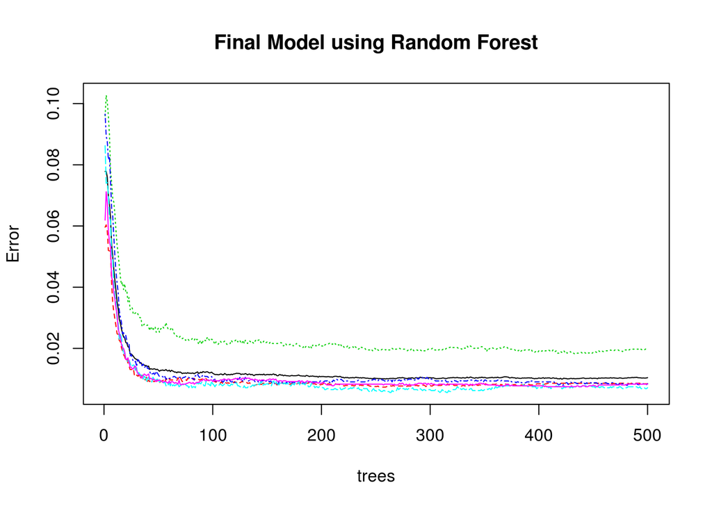

**Figure 4.0: Plotting the final model of random forest.**

## 6 Reference

[1]: Velloso, E.; Bulling, A.; Gellersen, H.; Ugulino, W.; Fuks, H., http://groupware.les.inf.puc-rio.br/har. Qualitative Activity Recognition of Weight Lifting Exercise. Proceedings of 4th International Conference in Cooperation with SIGCHI (Augmented Human ’13). Stuttgart, Germany: ACM SIGCHI, 2013.

[2]: Mark A. Hall, Correlation-based Feature Selection for Machine Learning